# Regression Analysis using an OLSR linear (lm) model and a CART (rpart) model

ASLIHAN DEMIRKAYA

## *Introduction*

In this work, our aim is to do regression analysis using an OLSR linear (lm) model and a CART (rpart) model on the dataset `kc_house_data`. The dataset is obtained from Kaggle.

The dataset consists of data of houses sold between May 2014 to May 2015. Our `lm` and `rpart` models will predict the sales of houses in King County with an accuracy of at least 70-78%.

## *Exploring the Data Set*

First let’s read the data `kc_house_data` and explore the data.

```r
kc_house_data<-read.csv('kc_house_data.csv')
dim(kc_house_data)
```

```
## [1] 21613    21
```

```r
names(kc_house_data)
```

```
##  [1] "id"            "date"          "price"         "bedrooms"
##  [5] "bathrooms"     "sqft_living"   "sqft_lot"      "floors"
##  [9] "waterfront"    "view"          "condition"     "grade"
## [13] "sqft_above"    "sqft_basement" "yr_built"      "yr_renovated"
## [17] "zipcode"       "lat"           "long"          "sqft_living15"
## [21] "sqft_lot15"
```

In this data set, we have 21,613 observations and 21 variables. In this problem, our response varibale is `price`. The explanatory variables are the rest of the variables. Now let’s classify the variables.

```r
library(dplyr)
```

```r
library(ggplot2)
glimpse(kc_house_data)
```

```
## Observations: 21,613
## Variables: 21
## $ id            <dbl> 7129300520, 6414100192, 5631500400, 2487200875, ...
## $ date          <fct> 20141013T000000, 20141209T000000, 20150225T00000...
## $ price         <dbl> 221900, 538000, 180000, 604000, 510000, 1225000,...
## $ bedrooms      <int> 3, 3, 2, 4, 3, 4, 3, 3, 3, 3, 3, 2, 3, 3, 5, 4, ...
## $ bathrooms     <dbl> 1.00, 2.25, 1.00, 3.00, 2.00, 4.50, 2.25, 1.50, ...
## $ sqft_living   <int> 1180, 2570, 770, 1960, 1680, 5420, 1715, 1060, 1...
## $ sqft_lot      <int> 5650, 7242, 10000, 5000, 8080, 101930, 6819, 971...
## $ floors        <dbl> 1.0, 2.0, 1.0, 1.0, 1.0, 1.0, 2.0, 1.0, 1.0, 2.0...
## $ waterfront    <int> 0, 0, 0, 0, 0, 0, 0, 0, 0, 0, 0, 0, 0, 0, 0, 0, ...
## $ view          <int> 0, 0, 0, 0, 0, 0, 0, 0, 0, 0, 0, 0, 0, 0, 0, 3, ...
## $ condition     <int> 3, 3, 3, 5, 3, 3, 3, 3, 3, 3, 3, 4, 4, 4, 3, 3, ...
## $ grade         <int> 7, 7, 6, 7, 8, 11, 7, 7, 7, 7, 8, 7, 7, 7, 7, 9,...
## $ sqft_above    <int> 1180, 2170, 770, 1050, 1680, 3890, 1715, 1060, 1...
## $ sqft_basement <int> 0, 400, 0, 910, 0, 1530, 0, 0, 730, 0, 1700, 300...
## $ yr_built      <int> 1955, 1951, 1933, 1965, 1987, 2001, 1995, 1963, ...
## $ yr_renovated  <int> 0, 1991, 0, 0, 0, 0, 0, 0, 0, 0, 0, 0, 0, 0, 0, ...
## $ zipcode       <int> 98178, 98125, 98028, 98136, 98074, 98053, 98003,...
## $ lat           <dbl> 47.5112, 47.7210, 47.7379, 47.5208, 47.6168, 47....
## $ long          <dbl> -122.257, -122.319, -122.233, -122.393, -122.045...
## $ sqft_living15 <int> 1340, 1690, 2720, 1360, 1800, 4760, 2238, 1650, ...
## $ sqft_lot15    <int> 5650, 7639, 8062, 5000, 7503, 101930, 6819, 9711...
```

By looking at the data, we can tell that we have one factor variable: `date` and the other variables are numerical.

### * Dealing with the variable: `date`*

We need to work on the variable `date` since it is not in a format we want it to be. We install the package `lubridate` for that purpose. We would like to categorize the date data into four classes: `winter`, `spring`, `summer` and `fall`. The following R-code does what we want.

```r
library("lubridate")
month_sold<-month(lubridate::parse_date_time(kc_house_data$date,"ymdHMS"))
kc_house_data$seasons<-
  cut((month_sold)%%12, breaks = c(-0.1,2.1, 5.1, 8.1, 11.1),
      labels = c("winter", "spring", "summer", "fall"),
      include.lowest = TRUE)
```

### * Dealing with the variable: `long, lat and zipcode`*

We need to work on these variables since we believe that the association with the house prices are highly not linear. There are several ways to deal with these variables but to make it simple, in this work, we will add a new variable that will somehow represent these variables. We will take the mean of the houses that belong to the same zipcode and call this variable as `zipcode_avg`.

```r
kc_house_data<-kc_house_data%>%
group_by(zipcode)%>%
  mutate(zipcode_avg=mean(price), zipcode_med=median(price))
glimpse(kc_house_data)
```

```
## Observations: 21,613
## Variables: 24
## $ id            <dbl> 7129300520, 6414100192, 5631500400, 2487200875, ...
## $ date          <fct> 20141013T000000, 20141209T000000, 20150225T00000...
## $ price         <dbl> 221900, 538000, 180000, 604000, 510000, 1225000,...
## $ bedrooms      <int> 3, 3, 2, 4, 3, 4, 3, 3, 3, 3, 3, 2, 3, 3, 5, 4, ...
## $ bathrooms     <dbl> 1.00, 2.25, 1.00, 3.00, 2.00, 4.50, 2.25, 1.50, ...
## $ sqft_living   <int> 1180, 2570, 770, 1960, 1680, 5420, 1715, 1060, 1...
## $ sqft_lot      <int> 5650, 7242, 10000, 5000, 8080, 101930, 6819, 971...
## $ floors        <dbl> 1.0, 2.0, 1.0, 1.0, 1.0, 1.0, 2.0, 1.0, 1.0, 2.0...
## $ waterfront    <int> 0, 0, 0, 0, 0, 0, 0, 0, 0, 0, 0, 0, 0, 0, 0, 0, ...
## $ view          <int> 0, 0, 0, 0, 0, 0, 0, 0, 0, 0, 0, 0, 0, 0, 0, 3, ...
## $ condition     <int> 3, 3, 3, 5, 3, 3, 3, 3, 3, 3, 3, 4, 4, 4, 3, 3, ...
## $ grade         <int> 7, 7, 6, 7, 8, 11, 7, 7, 7, 7, 8, 7, 7, 7, 7, 9,...
## $ sqft_above    <int> 1180, 2170, 770, 1050, 1680, 3890, 1715, 1060, 1...
## $ sqft_basement <int> 0, 400, 0, 910, 0, 1530, 0, 0, 730, 0, 1700, 300...
## $ yr_built      <int> 1955, 1951, 1933, 1965, 1987, 2001, 1995, 1963, ...
## $ yr_renovated  <int> 0, 1991, 0, 0, 0, 0, 0, 0, 0, 0, 0, 0, 0, 0, 0, ...
## $ zipcode       <int> 98178, 98125, 98028, 98136, 98074, 98053, 98003,...
## $ lat           <dbl> 47.5112, 47.7210, 47.7379, 47.5208, 47.6168, 47....
## $ long          <dbl> -122.257, -122.319, -122.233, -122.393, -122.045...
## $ sqft_living15 <int> 1340, 1690, 2720, 1360, 1800, 4760, 2238, 1650, ...
## $ sqft_lot15    <int> 5650, 7639, 8062, 5000, 7503, 101930, 6819, 9711...
## $ seasons       <fct> fall, winter, winter, winter, winter, spring, su...
## $ zipcode_avg   <dbl> 310612.8, 469455.8, 462480.0, 551688.7, 685605.8...
## $ zipcode_med   <dbl> 278277, 425000, 445000, 489950, 642000, 635000, ...
```

```r
length(kc_house_data$zipcode_avg)
```

```
## [1] 21613
```

### * Dropping the variables: `date, id, long, lat, zipcode`*

It makes sense to drop the variable `date` since we add a new variable `seasons`. Similarly we will drop `zipcode`, `lat` and `long`. We also drop the variable `id` since we believe that it has no effect on `price`.

```r
kc_house_data<-kc_house_data%>%
  ungroup(-zipcode)%>%
select(-c(id, date,zipcode,lat,long))
glimpse(kc_house_data)
```

```
## Observations: 21,613
## Variables: 19
## $ price         <dbl> 221900, 538000, 180000, 604000, 510000, 1225000,...
## $ bedrooms      <int> 3, 3, 2, 4, 3, 4, 3, 3, 3, 3, 3, 2, 3, 3, 5, 4, ...
## $ bathrooms     <dbl> 1.00, 2.25, 1.00, 3.00, 2.00, 4.50, 2.25, 1.50, ...
## $ sqft_living   <int> 1180, 2570, 770, 1960, 1680, 5420, 1715, 1060, 1...
## $ sqft_lot      <int> 5650, 7242, 10000, 5000, 8080, 101930, 6819, 971...
## $ floors        <dbl> 1.0, 2.0, 1.0, 1.0, 1.0, 1.0, 2.0, 1.0, 1.0, 2.0...
## $ waterfront    <int> 0, 0, 0, 0, 0, 0, 0, 0, 0, 0, 0, 0, 0, 0, 0, 0, ...
## $ view          <int> 0, 0, 0, 0, 0, 0, 0, 0, 0, 0, 0, 0, 0, 0, 0, 3, ...
## $ condition     <int> 3, 3, 3, 5, 3, 3, 3, 3, 3, 3, 3, 4, 4, 4, 3, 3, ...
## $ grade         <int> 7, 7, 6, 7, 8, 11, 7, 7, 7, 7, 8, 7, 7, 7, 7, 9,...
## $ sqft_above    <int> 1180, 2170, 770, 1050, 1680, 3890, 1715, 1060, 1...
## $ sqft_basement <int> 0, 400, 0, 910, 0, 1530, 0, 0, 730, 0, 1700, 300...
## $ yr_built      <int> 1955, 1951, 1933, 1965, 1987, 2001, 1995, 1963, ...
## $ yr_renovated  <int> 0, 1991, 0, 0, 0, 0, 0, 0, 0, 0, 0, 0, 0, 0, 0, ...
## $ sqft_living15 <int> 1340, 1690, 2720, 1360, 1800, 4760, 2238, 1650, ...
## $ sqft_lot15    <int> 5650, 7639, 8062, 5000, 7503, 101930, 6819, 9711...
## $ seasons       <fct> fall, winter, winter, winter, winter, spring, su...
## $ zipcode_avg   <dbl> 310612.8, 469455.8, 462480.0, 551688.7, 685605.8...
## $ zipcode_med   <dbl> 278277, 425000, 445000, 489950, 642000, 635000, ...
```

### * Visualizing the data*

In this section, we are going to pick some random variables and visually observe if they have some effects on the variable `price`.

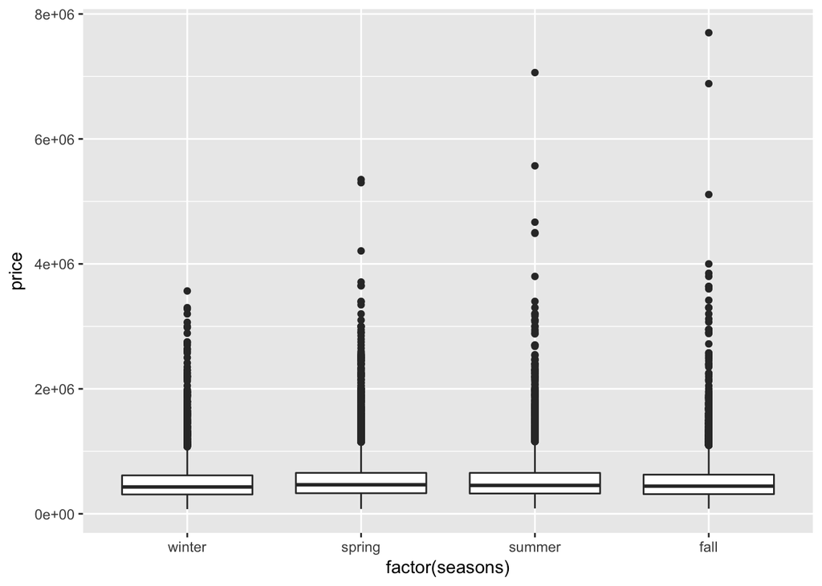

```r
ggplot(data = kc_house_data, aes(x = factor(seasons), y = price)) +
geom_boxplot()
```

The boxplot `price` vs `seasons` shows us `seasons` does not play a significant role in predicting `price` since the statistics of each category seem close.

Now let’s see if `grade` has some effect on `price`.

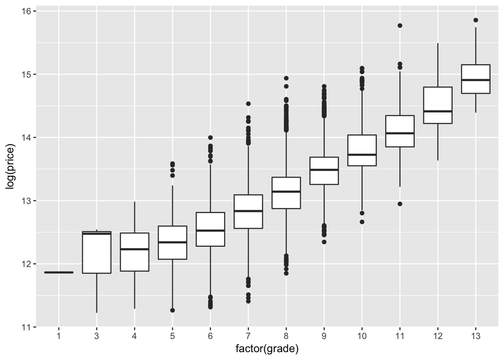

```r
ggplot(data = kc_house_data, aes(x = factor(grade), y = log(price))) +
geom_boxplot()
```

The boxplot shows us the variable `grade` has a significant effect on the `price` variable since the statistics of each class highly varies from each other.

Similarly, we can see if `view` has some effect on the price.

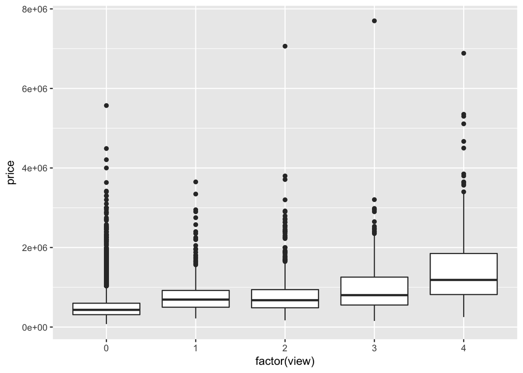

```r
ggplot(data = kc_house_data, aes(x = factor(view), y = price)) +
geom_boxplot()
```

We see that there is a difference between `view=0` and `view=4`. So we expect `view` to have an effect on the variable `price`.

Now, let’s study the relation between `sqft_living` and `price`.

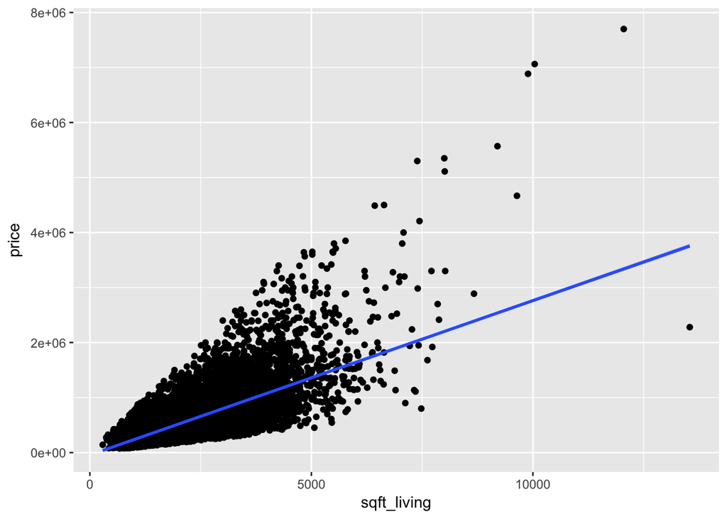

```r
ggplot(data=kc_house_data,aes(x = sqft_living, y = price )) +
geom_point()+
geom_smooth(method=lm)
```

We see a fan shape, so the relation between `sqft_living` and `price` is nonlinear. We will try taking the `log` of the response variable to get better results.

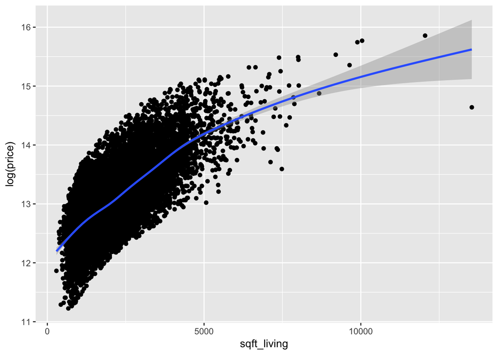

```r
ggplot(data=kc_house_data,aes(x = sqft_living, y = log(price) )) +
geom_point()+
geom_smooth()
```

By looking at the plot, we can say that `log(price)` and `sqft_living` has some nonlinear relationship. The regression curve (blue) looks like a square root function. So we are going to add `sqrt(sqft_living)` in our `lm` model when we take the log of `price`.

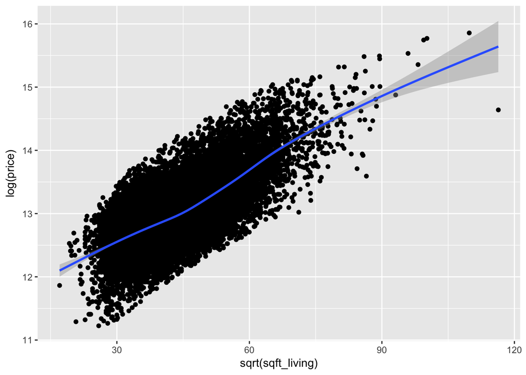

```r
ggplot(data=kc_house_data,aes(x = sqrt(sqft_living), y = log(price) )) +
geom_point()+
geom_smooth()
```

As seen in the plot, the relation between `sqrt(sqrt_living)` and `log(price)` looks like linear.

We expect a relationship between the mean price of each zipcode and the proce of the houses, Below we see that relation.

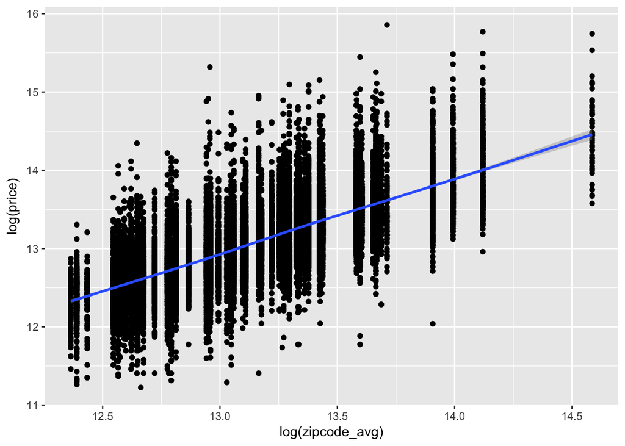

```r
ggplot(data=kc_house_data,aes(x = log(zipcode_avg), y = log(price))) +
geom_point()+
geom_smooth()
```

### *Preparing the Data Set*

Since we are going to compare models and select the best model at the end of the section, we will split our data into training and testing (80/20). Then we will split the training data into training and validation (again, 80/20).

Below is the R-code that helps us to split our data set into two sets: Training and Testing data.

```r
set.seed(123)
rows <- sample(nrow(kc_house_data)) #randomly order the sampled data
kc_house_data <- kc_house_data[rows, ]
split <- round(nrow(kc_house_data) * .80)
train <- kc_house_data[1:split, ]
test_set <- kc_house_data[(split + 1):nrow(kc_house_data), ]
```

Now, we split our Training Data into two sets: Training and Validation data.

```r
set.seed(123)
rows <- sample(nrow(train)) #randomly order the sampled data
train <- train[rows, ]
split <- round(nrow(train) * .80)
train_set <- train[1:split, ]
validation_set <- train[(split + 1):nrow(train), ]
```

In short, we have three sets now: train_set which has 64% of the data, validation_set which has 16% of the data and test_set which has the 20% of the data.

```r
print(c(dim(train_set),dim(validation_set),dim(test_set)))
```

```
## [1] 13832    19  3458    19  4323    19
```

## *Fitting models using `lm` and `rpart`*

### *OLSR Linear (lm) Model:*

In this section, we will present a few `lm` models and calculate their corresponding `RMSE` values. We will pick the most optimal one at the end of this section.

#### * Simple Model:* Our first linear model will be the one that anyone can start without exploring any kind of relationsip between the response variable and the features. We will run our model in the train set: train_set. Here is the R-command for the model:

```r
mod_1<-lm(price~., data=train_set)
summary(mod_1)
```

```
##
## Call:
## lm(formula = price ~ ., data = train_set)
##
## Residuals:
##      Min       1Q   Median       3Q      Max
## -1049975   -77888     -761    68983  4320242
##
## Coefficients: (1 not defined because of singularities)
##                 Estimate Std. Error t value Pr(>|t|)
## (Intercept)    3.146e+06  1.469e+05  21.423  < 2e-16 ***
## bedrooms      -3.493e+04  2.061e+03 -16.948  < 2e-16 ***
## bathrooms      3.022e+04  3.585e+03   8.429  < 2e-16 ***
## sqft_living    1.669e+02  4.858e+00  34.356  < 2e-16 ***
## sqft_lot       1.491e-01  5.456e-02   2.733 0.006276 **
## floors        -8.314e+03  3.923e+03  -2.119 0.034089 *
## waterfront     6.219e+05  1.865e+04  33.352  < 2e-16 ***
## view           5.992e+04  2.349e+03  25.507  < 2e-16 ***
## condition      9.380e+03  2.573e+03   3.646 0.000267 ***
## grade          6.509e+04  2.395e+03  27.173  < 2e-16 ***
## sqft_above     4.197e+01  4.736e+00   8.862  < 2e-16 ***
## sqft_basement         NA         NA      NA       NA
## yr_built      -1.921e+03  7.557e+01 -25.424  < 2e-16 ***
## yr_renovated   4.676e+00  4.050e+00   1.155 0.248299
## sqft_living15 -3.662e+01  3.764e+00  -9.730  < 2e-16 ***
## sqft_lot15    -3.654e-01  8.089e-02  -4.518 6.30e-06 ***
## seasonsspring  2.101e+04  4.572e+03   4.596 4.35e-06 ***
## seasonssummer -7.425e+03  4.599e+03  -1.614 0.106471
## seasonsfall   -9.840e+03  4.801e+03  -2.050 0.040410 *
## zipcode_avg    8.211e-01  5.090e-02  16.130  < 2e-16 ***
## zipcode_med   -1.928e-01  6.077e-02  -3.172 0.001519 **
## ---
## Signif. codes:  0 '***' 0.001 '**' 0.01 '*' 0.05 '.' 0.1 ' ' 1
##
## Residual standard error: 178100 on 13812 degrees of freedom
## Multiple R-squared:  0.778,  Adjusted R-squared:  0.7777
## F-statistic:  2548 on 19 and 13812 DF,  p-value: < 2.2e-16
```

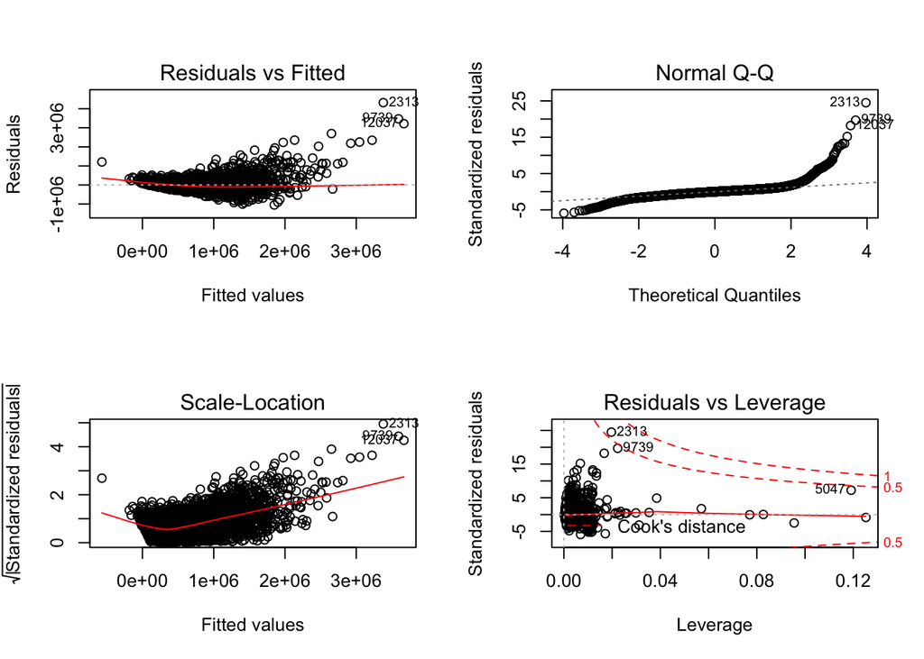

```r
par(mfrow=c(2,2))
plot(mod_1)
```

#### * Discussion of the summary statistics of the model:*

Before we discuss about the p-values, notice that we have `NA` values in the row of `sqft_basement`. The reason is the collinearity. `sqft_basement` linearly depends on the other two variables: `sqft_living` and `sqft_above`, i.e., we can write `sqft_basement=sqft_living-sqft_above`.

#### * Model with excluding insignificant variables:*

```r
mod_2<-lm(price~.-floors-sqft_lot-sqft_basement-seasons-yr_renovated, data=train_set)
summary(mod_2)
```

```
##
## Call:
## lm(formula = price ~ . - floors - sqft_lot - sqft_basement -
##     seasons - yr_renovated, data = train_set)
##
## Residuals:
##      Min       1Q   Median       3Q      Max
## -1063951   -78060     -218    68603  4313713
##
## Coefficients:
##                 Estimate Std. Error t value Pr(>|t|)
## (Intercept)    3.258e+06  1.384e+05  23.534  < 2e-16 ***
## bedrooms      -3.489e+04  2.064e+03 -16.903  < 2e-16 ***
## bathrooms      2.848e+04  3.430e+03   8.302  < 2e-16 ***
## sqft_living    1.705e+02  4.643e+00  36.721  < 2e-16 ***
## waterfront     6.220e+05  1.868e+04  33.303  < 2e-16 ***
## view           5.989e+04  2.351e+03  25.477  < 2e-16 ***
## condition      8.732e+03  2.534e+03   3.446 0.000570 ***
## grade          6.491e+04  2.387e+03  27.196  < 2e-16 ***
## sqft_above     3.747e+01  4.283e+00   8.749  < 2e-16 ***
## yr_built      -1.979e+03  7.125e+01 -27.778  < 2e-16 ***
## sqft_living15 -3.595e+01  3.712e+00  -9.685  < 2e-16 ***
## sqft_lot15    -1.922e-01  5.691e-02  -3.377 0.000735 ***
## zipcode_avg    8.181e-01  5.101e-02  16.038  < 2e-16 ***
## zipcode_med   -1.918e-01  6.089e-02  -3.151 0.001632 **
## ---
## Signif. codes:  0 '***' 0.001 '**' 0.01 '*' 0.05 '.' 0.1 ' ' 1
##
## Residual standard error: 178700 on 13818 degrees of freedom
## Multiple R-squared:  0.7766, Adjusted R-squared:  0.7764
## F-statistic:  3696 on 13 and 13818 DF,  p-value: < 2.2e-16
```

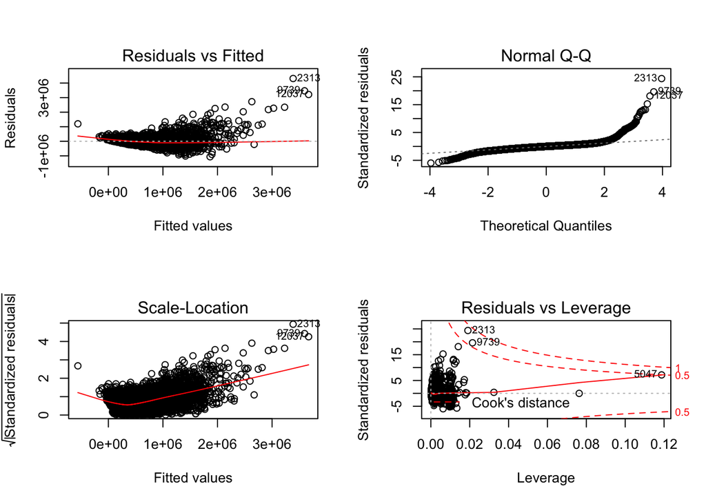

```r
par(mfrow=c(2,2))
plot(mod_2)
```

Looking at the summary, we can tell that all the variables play a significant role assuming the significance level as (=0.05).

#### *Model with the log of the response variable:*

As we mentioned earlier, `sqft_living` vs `price` plot has a fan shape. It is worth trying to take the log of the response variable: `price`. We will work on this as our next model.

```r
mod_3<-lm(log(price)~.-floors-sqft_lot-sqft_basement-seasons-yr_renovated-zipcode_avg-zipcode_med+log(zipcode_med)+log(zipcode_avg), data=train_set)
summary(mod_3)
```

```
##
## Call:
## lm(formula = log(price) ~ . - floors - sqft_lot - sqft_basement -
##     seasons - yr_renovated - zipcode_avg - zipcode_med + log(zipcode_med) +
##     log(zipcode_avg), data = train_set)
##
## Residuals:
##      Min       1Q   Median       3Q      Max
## -1.08674 -0.12034  0.00371  0.12360  1.03214
##
## Coefficients:
##                    Estimate Std. Error t value Pr(>|t|)
## (Intercept)       7.443e+00  1.864e-01  39.922  < 2e-16 ***
## bedrooms         -7.433e-03  2.399e-03  -3.098  0.00195 **
## bathrooms         6.444e-02  3.988e-03  16.158  < 2e-16 ***
## sqft_living       1.500e-04  5.394e-06  27.806  < 2e-16 ***
## waterfront        3.883e-01  2.170e-02  17.896  < 2e-16 ***
## view              6.860e-02  2.735e-03  25.079  < 2e-16 ***
## condition         2.738e-02  2.943e-03   9.304  < 2e-16 ***
## grade             1.166e-01  2.787e-03  41.858  < 2e-16 ***
## sqft_above        2.361e-05  4.977e-06   4.745  2.1e-06 ***
## yr_built         -2.545e-03  8.292e-05 -30.691  < 2e-16 ***
## sqft_living15     5.552e-06  4.304e-06   1.290  0.19707
## sqft_lot15        1.534e-07  6.607e-08   2.321  0.02029 *
## log(zipcode_med)  3.819e-01  3.797e-02  10.056  < 2e-16 ***
## log(zipcode_avg)  3.175e-01  3.581e-02   8.866  < 2e-16 ***
## ---
## Signif. codes:  0 '***' 0.001 '**' 0.01 '*' 0.05 '.' 0.1 ' ' 1
##
## Residual standard error: 0.2076 on 13818 degrees of freedom
## Multiple R-squared:  0.8453, Adjusted R-squared:  0.8452
## F-statistic:  5808 on 13 and 13818 DF,  p-value: < 2.2e-16
```

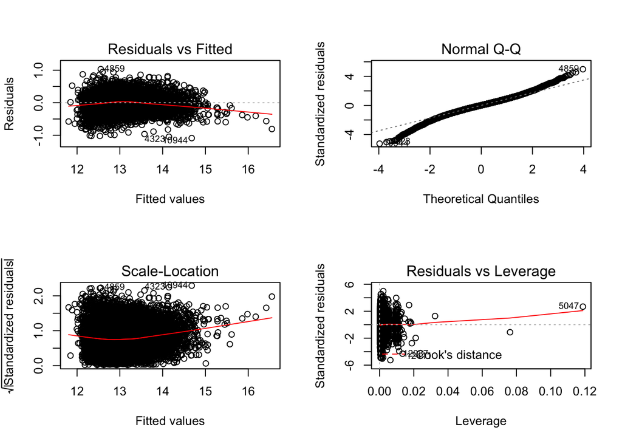

```r
par(mfrow=c(2,2))
plot(mod_3)
```

When we look at the statistics, it looks like we get better results as compared to the previous `lm` models. However, we have to be careful because our response variable is in the log form. In the next section, we will compare all these three models.

### *Comparison of the `lm` models:*

```r
pred1 <- predict(object = mod_1,newdata = validation_set)
pred2 <- predict(object = mod_2,newdata = validation_set)
pred3 <- exp(predict(object = mod_3,newdata = validation_set)) #since the prediction is in log form.

actual<-validation_set$price

re_mod1<-median(abs((pred1 - actual)/actual)) #relative error
re_mod2<-median(abs((pred2 - actual)/actual))
re_mod3<-median(abs((pred3 - actual)/actual))

re_lm_all<-c(re_mod1, re_mod2, re_mod3)
print(re_lm_all)
```

```
## [1] 0.1552964 0.1578398 0.1193639
```

Looking at the R-squared values and the relative errors calculated above, we can say the best linear model out of three models is `mod_3` with the relative error 11.9%.

### * CART (rpart) Model:*

In this section, we will fit our data to rpart model. Our parameters will be taken as the default values. Following this model, we will work on the hyperparameters. First we will play with the complexity parameter and present a model with the optimal complex parameter cp. Given that fixed cp, we will do grid search. We will present RMSE values for every optimal model we find in this section. At the end of the section, we will present our winner.

#### *Simple `rpart` model with default settings:*

```r
library(rpart)
set.seed(1)
rpart_model <- rpart(formula = price ~.,
data = train_set,
method = "anova") #since it is regression model, we pick "anova".
rpart_model
```

```
## n= 13832
##
## node), split, n, deviance, yval
##       * denotes terminal node
##
##  1) root 13832 1.974421e+15  540698.2
##    2) grade< 9.5 12772 7.395538e+14  479434.0
##      4) zipcode_avg< 539824.9 7255 1.546703e+14  360781.9
##        8) sqft_living< 2275 5432 6.088037e+13  317628.7 *
##        9) sqft_living>=2275 1823 5.353355e+13  489365.4 *
##      5) zipcode_avg>=539824.9 5517 3.484306e+14  635464.8
##       10) sqft_living< 2345.5 3819 1.003059e+14  543762.5 *
##       11) sqft_living>=2345.5 1698 1.437788e+14  841713.9
##         22) zipcode_avg< 861255 1449 7.679216e+13  784451.1 *
##         23) zipcode_avg>=861255 249 3.458621e+13 1174942.0 *
##    3) grade>=9.5 1060 6.093331e+14 1278873.0
##      6) sqft_living< 5005 929 2.340396e+14 1131966.0
##       12) view< 3.5 867 1.532965e+14 1068380.0
##         24) zipcode_avg< 861255 722 6.730145e+13  957969.1 *
##         25) zipcode_avg>=861255 145 3.336759e+13 1618150.0 *
##       13) view>=3.5 62 2.821806e+13 2021145.0 *
##      7) sqft_living>=5005 131 2.130613e+14 2320682.0
##       14) sqft_living< 7940 123 1.068015e+14 2114984.0
##         28) zipcode_avg< 861255 89 5.365050e+13 1801511.0 *
##         29) zipcode_avg>=861255 34 2.151245e+13 2935546.0 *
##       15) sqft_living>=7940 8 2.103882e+13 5483288.0 *
```

This summary tells us which variables and the cutoff values are taken in the construction of the regression tree but it helps more when we see those variables and the values visually. Below is the regression tree for this model:

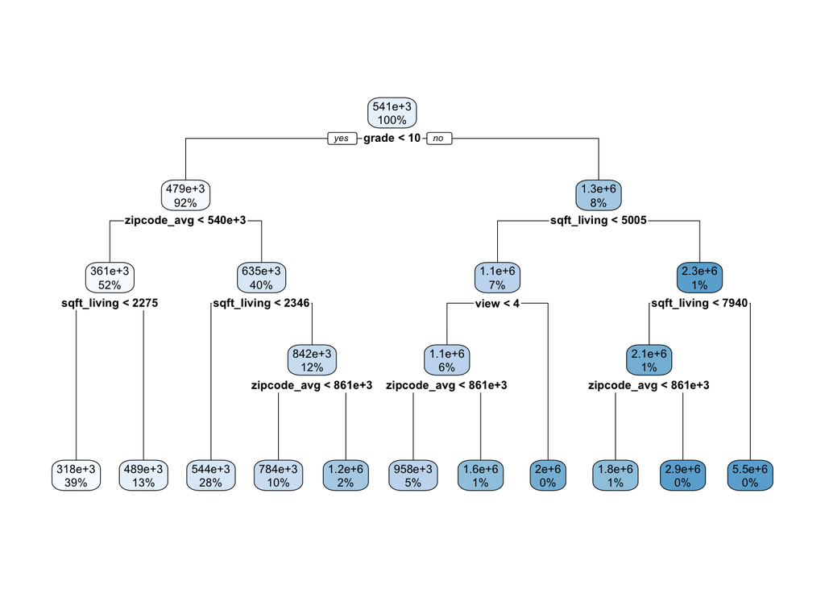

```r
library(rpart.plot)
rpart.plot(rpart_model)
```

Now, let’s evaluate the RMSE for our first rpart model: rpart_model on the validation_set.

```r
pred <- predict(object = rpart_model,newdata = validation_set)
actual<-validation_set$price
rmse<-sqrt(mean((pred - actual)^2))
print(rmse)
```

```
## [1] 211764.2
```

#### * Playing with the hyperparameters:*

In this section, for a better model, we will work on the hyperparameters. First, we will start with finding the optimal complex parameter cp. Then we will do the grid search.

#### * Finding an optimal `cp`:*

First, let’s plot X-val Relative Error vs cp plot.

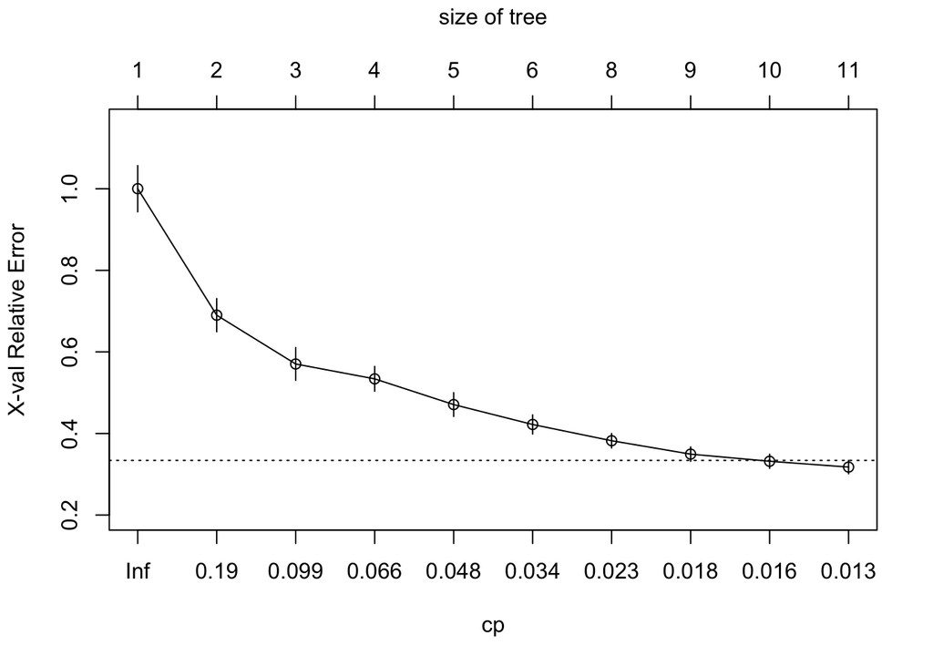

```r
plotcp(rpart_model)
```

```r
print(rpart_model$cptable)
```

```
##            CP nsplit rel error    xerror       xstd
## 1  0.31681893      0 1.0000000 1.0001658 0.05667259
## 2  0.11975813      1 0.6831811 0.6900816 0.04062542
## 3  0.08216701      2 0.5634229 0.5703713 0.04027944
## 4  0.05284883      3 0.4812559 0.5339332 0.03037637
## 5  0.04316249      4 0.4284071 0.4708683 0.02913376
## 6  0.02662869      5 0.3852446 0.4220598 0.02339724
## 7  0.02038897      7 0.3319872 0.3822336 0.01772466
## 8  0.01641010      8 0.3115982 0.3493672 0.01754946
## 9  0.01602423      9 0.2951881 0.3318806 0.01733064
## 10 0.01000000     10 0.2791639 0.3176185 0.01639752
```

```r
opt_index <- which.min(rpart_model$cptable[, "xerror"])
cp_opt <- rpart_model$cptable[opt_index, "CP"]
print(cp_opt)
```

```
## [1] 0.01
```

```r
model_opt <- prune(tree = rpart_model, cp = cp_opt)
```

Since the optimal cp is the default value, model_opt is same as our first rpart model: rpart_model.

However, we are curious if we get smaller RMSE values with lower cp values. We believe it is worth trying. So we write a for loop for cp values less than 0.01.

```r
set.seed(1)
 small_cp_models <- list()
for (i in 1:9) {
    small_cp_models[[i]] <- rpart(formula = price ~ .,
                               data =train_set ,
                               method = "anova",
                               cp=0.001*i)
}
```

The R-code above gives us 9 models with cp values $\in$ {0.001,0.002,…,0.009}. We calculate their RMSE values on the validation set as follows:

```r
rmse_values <- c()
for (i in 1:length(small_cp_models)) {
model <-small_cp_models[[i]]
pred <- predict(object = model,newdata = validation_set)
actual<-validation_set$price
rmse_values[i] <- sqrt(mean((pred - actual)^2)) #rmse values for cp=c(0.001,0.002,...,0.009)
}
print(rmse_values)
```

```
## [1] 172974.6 179510.6 182077.6 189410.4 196169.1 201752.6 204598.2 208069.8
## [9] 208069.8
```

The RMSE value takes its minimum value when cp=0.001. Note that, we have to check if the X-val Relative Error remains small, too. Below, we present the cp plot for small cp values as the verification.

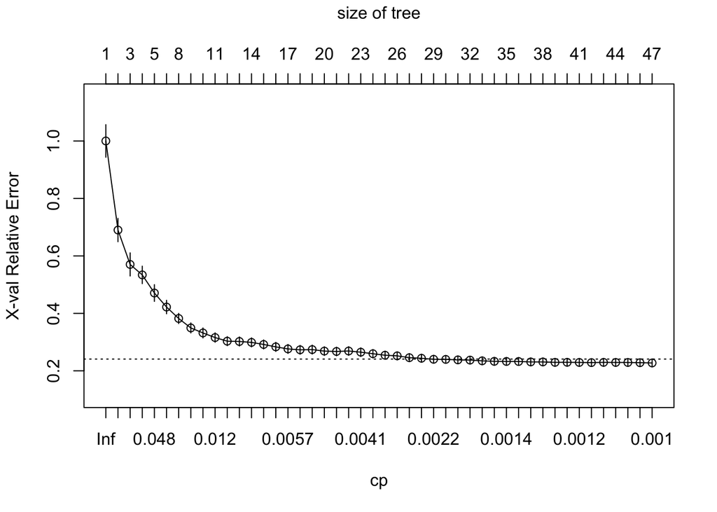

```r
rpart_cp_0001 <- small_cp_models[[1]] # cp=0.001
plotcp(rpart_cp_0001)
```

```r
print(rpart_cp_0001$cptable)
```

```
##             CP nsplit rel error    xerror       xstd
## 1  0.316818928      0 1.0000000 1.0001658 0.05667259
## 2  0.119758132      1 0.6831811 0.6900816 0.04062542
## 3  0.082167006      2 0.5634229 0.5703713 0.04027944
## 4  0.052848835      3 0.4812559 0.5339332 0.03037637
## 5  0.043162494      4 0.4284071 0.4708683 0.02913376
## 6  0.026628694      5 0.3852446 0.4220598 0.02339724
## 7  0.020388972      7 0.3319872 0.3822336 0.01772466
## 8  0.016410096      8 0.3115982 0.3493672 0.01754946
## 9  0.016024226      9 0.2951881 0.3318806 0.01733064
## 10 0.009719506     10 0.2791639 0.3158539 0.01637058
## 11 0.007510740     11 0.2694444 0.3032235 0.01581010
## 12 0.007231187     12 0.2619337 0.3021959 0.01580910
## 13 0.006895537     13 0.2547025 0.2990206 0.01580090
## 14 0.006340971     14 0.2478070 0.2918059 0.01579570
```

[output cut: 32 more lines]

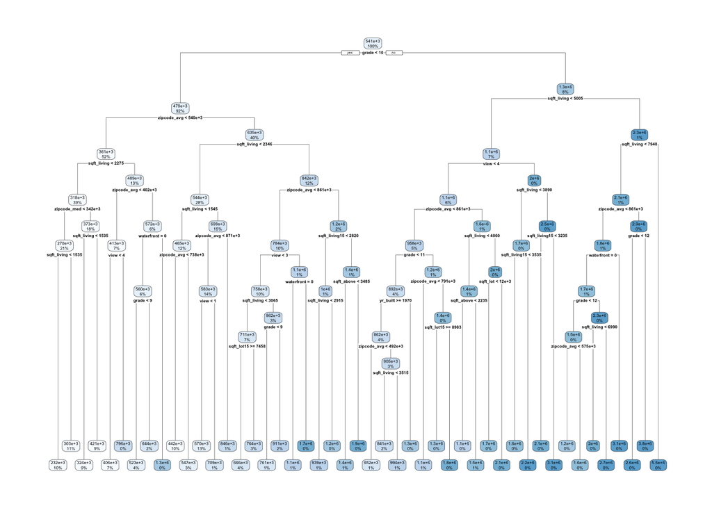

```r
rpart.plot(rpart_cp_0001)
```

#### * Doing a grid search:*

Now, let’s set up the grid by establishing a list of possible values for minsplit and maxdepth.

```r
minsplit <- seq(2, 10, 1)
maxdepth <- seq(4, 10, 1)
hyper_grid <- expand.grid(minsplit = minsplit,maxdepth = maxdepth)
head(hyper_grid)
```

```
##   minsplit maxdepth
## 1        2        4
## 2        3        4
## 3        4        4
## 4        5        4
## 5        6        4
## 6        7        4
```

In the above R-code, minsplit takes values from 2 to 10 and similarly, maxdepth takes values from 4 to 10. So in total, we have 9×7=63 pairs. Below, we write `rpart` models for these 63 pairs. Thus in total we present 63 models. As usual, we fit all these models on the train_set. Note that, we will take cp as 0.001 since it was the optimal cp value we found earlier.

```r
set.seed(1)
# Number of potential models in the grid
num_models <- nrow(hyper_grid)

# Create an empty list to store models
rpart_grid_models <- list()

# Write a loop over the rows of hyper_grid to train the grid of models
for (i in 1:num_models) {

    # Get minsplit, maxdepth values at row i
    minsplit <- hyper_grid$minsplit[i]
    maxdepth <- hyper_grid$maxdepth[i]

    # Train a model and store in the list
    rpart_grid_models[[i]] <- rpart(formula = price ~ .,
                               data =train_set ,
                               method = "anova",
                               minsplit = minsplit,
                               maxdepth = maxdepth,
                               cp=0.001
                               )
}
```

Now, we constructed 63 rpart models but we have to pick the optimal one. The one with the smallest RMSE on the validation_set will be our optimal one.

```r
rmse_values <- c()
for (i in 1:length(rpart_grid_models)) {
model <- rpart_grid_models[[i]]
pred <- predict(object = model,newdata = validation_set)
actual<-validation_set$price
rmse_values[i] <- sqrt(mean((pred - actual)^2))
}
rmse_values
```

```
##  [1] 204961.3 204961.3 204961.3 204961.3 204961.3 204961.3 204961.3
##  [8] 200808.7 200808.7 186597.6 186597.6 186597.6 186597.6 186597.6
## [15] 186597.6 186597.6 182026.5 182026.5 179209.5 179209.5 179209.5
## [22] 179104.1 179104.1 179104.1 179319.0 174557.4 174557.4 177151.5
## [29] 177151.5 177151.5 177044.8 177044.8 177044.8 177267.9 172449.7
## [36] 172449.7 176704.9 176704.9 176704.9 176597.9 176597.9 176597.9
## [43] 176821.6 171990.9 171990.9 176704.9 176704.9 176704.9 176597.9
## [50] 176597.9 176597.9 176821.6 171990.9 171990.9 176704.9 176704.9
## [57] 176704.9 176597.9 176597.9 176597.9 176821.6 171990.9 171990.9
```

```r
best_grid_model <- rpart_grid_models[[which.min(rmse_values)]]
best_grid_model$control
```

```
## $minsplit
## [1] 9
##
## $minbucket
## [1] 3
##
## $cp
## [1] 0.001
##
## $maxcompete
## [1] 4
##
## $maxsurrogate
## [1] 5
##
## $usesurrogate
## [1] 2
##
## $surrogatestyle
## [1] 0
##
## $maxdepth
## [1] 8
##
## $xval
## [1] 10
```

#### * Comparison of the `rpart` models:*

```r
pred1 <- predict(object = rpart_model,newdata = validation_set)
pred2 <- predict(object = rpart_cp_0001,newdata = validation_set)
pred3 <- predict(object = best_grid_model,newdata = validation_set)


actual<-validation_set$price
re_1<-median(abs((pred1 - actual)/actual))
re_2<-median(abs((pred2 - actual)/actual))
re_3<-median(abs((pred3 - actual)/actual))

re_rpart_all<-c(re_1,re_2,re_3)
print(re_rpart_all)
```

```
## [1] 0.2052452 0.1405045 0.1405045
```

## *Conclusion*

```r
best_grid_model_full<- rpart(formula = price ~ .,
                               data =kc_house_data,
                               method = "anova",
                               minsplit = 9,
                               maxdepth = 10,
                               cp=0.001
                               )
```

Now we apply our model best_grid_model_full to test_set.

```r
pred <- predict(object = best_grid_model_full,newdata = test_set)
actual<-test_set$price
re_mod3<-median(abs((pred - actual)/actual))
print(c(rmse,re_mod3))
```

```
## [1] 2.117642e+05 1.417461e-01
```